# Факторный анализ

Литвинцев И.С

12 декабря 2017 г

## Факторный анализ

Исследуются данные о недоношенных младенцах, у которых вовремя не закрылся артериальный проток. Требуется по независимым переменным сделать факторный анализ и проверить, указывают ли факторы на дифференциацию по терапии и осложнениям.

Независимые признаки:

1. O2.1 Насыщение крови кислородом до
2. O2.2 Насыщение крови кислородом после
3. Diuresis1 Диурез до
4. Diuresis.2 Диурез после
5. PA1 Артериальное давление до
6. PA2 Артериальное давление после
7. Р.Р.1 Пульсовое давление до
8. PP2 Пульсовое давление после

Факторные переменные:

1. therapy - вид терапии
2. BLD - бронхо лёгочная дисплазия

### 1. Подготовка данных

```r
file <- "C:/Users/806263/Desktop/SPbU/Магистратура Матмех (2017-2019)/Применение статистических методов к реальным данным/Данные/baseMA.csv";
df <- read.csv(file, sep = ";", dec = ".")

features <- c("O2.1", "O2.2", "Diuresis1", "Diuresis.2", "PA1", "PA2", "Р.Р.1", "PP2")
classes <- c("BLD", "therapy")
X <- subset(df, select = features)
Y <- subset(df, select = classes)
df <- cbind(X, Y)

df <- na.omit(df)
head(df)
```

```
##   O2.1 O2.2 Diuresis1 Diuresis.2 PA1 PA2 Р.Р.1 PP2 BLD therapy
## 1 0.25 0.30      4.43       1.98  45  53    14  25   1       3
## 2 0.45 0.21      8.00       7.10  47  43    34  32   1       3
## 5 0.25 0.30      7.50       3.90  40  77    28  23   1       3
## 6 0.25 0.21      6.46       5.10  53  57    28  20   1       3
## 7 0.30 0.21      4.03       4.88  66  63    34  23   0       3
## 8 0.30 0.21      3.55       4.71  46  47    26  26   0       3
```

Для начала стандартизуем данные.

```r
X <- scale(df[ , features])
Y <- df[ , classes]
df <- cbind(X, Y)
n <- nrow(df)
```

### 2. Поиск главных компонент и факторов

Для начала необходимо найти собственные векторы матрицы $\mathrm{S}$:
$$\mathrm{S} = \mathrm{X}^T\mathrm{X}, \qquad \mathrm{S}U_i=\lambda_iU_i, \qquad (U_i, U_j)=0, \quad \forall i \neq j, \qquad \mathrm{U}=[U_1: \ldots : U_d],$$
где $d \le rank(\mathrm{S})$.

```r
S <- t(X)%*%X
S.eig <- eigen(S);
#install.packages('xtable')
#library("xtable")

U <- S.eig$vectors; U
```

```
##             [,1]        [,2]       [,3]        [,4]        [,5]
## [1,] -0.61327941 -0.04907161 -0.2368598  0.07899994 -0.22950831
## [2,] -0.65815840  0.05864058 -0.1821570  0.02073105 -0.09865128
## [3,] -0.27302578 -0.25750744  0.5018397 -0.36618311  0.40626329
## [4,] -0.26179898 -0.24873851  0.4206092  0.53753171  0.09438289
## [5,]  0.01149648 -0.38324133  0.4042069 -0.40490230 -0.55910521
## [6,] -0.03917090 -0.33674631 -0.4769474 -0.48458040  0.01369862
## [7,]  0.21160832 -0.55189010 -0.1529965  0.40215503 -0.38750409
## [8,]  0.03448920 -0.54874188 -0.2601753  0.09902588  0.54835222
##              [,6]        [,7]         [,8]
## [1,] -0.275047229  0.23098422  0.614376145
## [2,] -0.004149983 -0.16407233 -0.702217088
## [3,]  0.032829103  0.54653663 -0.091563291
## [4,]  0.490471219 -0.34101130  0.194882475
## [5,] -0.255022824 -0.38460734  0.010331637
## [6,]  0.629717893 -0.09059825  0.133530007
## [7,]  0.045815201  0.49817112 -0.255087678
## [8,] -0.467986897 -0.31690733 -0.007960532
```

```r
lambda <- S.eig$values; lambda
```

```
## [1] 186.73199 149.27450 136.47882 116.01331  95.82218  74.14261  53.76352
## [8]  35.77307
```

Теперь можно найти векторы главных компонент $\mathrm{Z} = [Z_1 : \ldots : Z_d]$.

$$\mathrm{Z} = \mathrm{X}\mathrm{U}.$$

```r
Z <- X%*%U;
head(Z)
```

```
##          [,1]        [,2]       [,3]       [,4]       [,5]       [,6]
## 1  0.97936962  1.88106790 -0.7690541 -1.2856966  0.2222575 -0.5688925
## 2 -0.06060582 -0.76948836  0.6719262  0.5428834  0.4699988 -0.9376175
## 5  0.56508432 -0.06234493 -0.9789616 -1.8108621  0.4428812  1.5223402
## 6  1.05873995  0.41400888  0.4011851 -0.9156880 -0.4842454  0.5301000
## 7  1.36223479 -0.40191883 -0.4839231 -0.7768875 -1.6921611  0.2737443
## 8  1.31247708  1.01711763 -0.5164759  0.2675932 -0.4112829 -0.5467230
##          [,7]        [,8]
## 1 -0.29659214 -0.09529477
## 2  1.42394956  0.74254582
## 5  1.21320308 -0.22646165
## 6  0.76864508  0.09792687
## 7 -0.06017905  0.34389833
## 8 -0.06948939  0.37539388
```

А также найдем факторы $V_i$ с помощью следующей формулы:
$$V_i = \frac{Z_i}{\sqrt{\lambda_i}}.$$

```r
V <- X%*%U/sqrt(lambda)
head(V)
```

```
##           [,1]         [,2]        [,3]        [,4]        [,5]
## 1  0.071669977  0.174642747 -0.10488492 -0.10523148  0.02270510
## 2 -0.004960455 -0.078608415  0.11234234  0.04647013  0.05458368
## 5  0.048370506 -0.007240478 -0.07164012 -0.16812468  0.06040090
## 6  0.098295895  0.056463243  0.03283613 -0.09354370 -0.08096315
## 7  0.139161453 -0.067198605 -0.04142321 -0.09022445 -0.12383185
## 8  0.152425558  0.074432364 -0.04795083  0.03649483 -0.03366262
##          [,6]         [,7]         [,8]
## 1 -0.09511568 -0.025387914 -0.011067133
## 2 -0.06861457  0.132202810  0.101269676
## 5  0.12460024  0.123936860 -0.037863136
## 6  0.04537590  0.089267200  0.007166259
## 7  0.02541506 -0.008207322  0.028147333
## 8 -0.05585144 -0.011618242  0.032133244
```

```r
V <- Z/sqrt(lambda)
head(V)
```

```
##           [,1]         [,2]        [,3]        [,4]        [,5]
## 1  0.071669977  0.174642747 -0.10488492 -0.10523148  0.02270510
## 2 -0.004960455 -0.078608415  0.11234234  0.04647013  0.05458368
## 5  0.048370506 -0.007240478 -0.07164012 -0.16812468  0.06040090
## 6  0.098295895  0.056463243  0.03283613 -0.09354370 -0.08096315
## 7  0.139161453 -0.067198605 -0.04142321 -0.09022445 -0.12383185
## 8  0.152425558  0.074432364 -0.04795083  0.03649483 -0.03366262
##          [,6]         [,7]         [,8]
## 1 -0.09511568 -0.025387914 -0.011067133
## 2 -0.06861457  0.132202810  0.101269676
## 5  0.12460024  0.123936860 -0.037863136
## 6  0.04537590  0.089267200  0.007166259
## 7  0.02541506 -0.008207322  0.028147333
## 8 -0.05585144 -0.011618242  0.032133244
```

И, наконец, найдем факторные нагрузки $F_i$:
$$F_i = \sqrt{\lambda_i}U_i, \qquad \mathrm{F}=[F_1:\ldots:F_d], \qquad (F_i)_j = cor(X_i, Z_j).$$

```r
F.loadings <- sqrt(lambda)*U; F.loadings
```

```
##            [,1]       [,2]      [,3]       [,4]       [,5]        [,6]
## [1,] -8.3804579 -0.6705632 -3.236687  1.0795335 -3.1362291 -3.75851806
## [2,] -8.0412440  0.7164586 -2.225557  0.2532877 -1.2053010 -0.05070364
## [3,] -3.1896004 -3.0083088  5.862699 -4.2779030  4.7461363  0.38352320
## [4,] -2.8198231 -2.6791495  4.530359  5.7897259  1.0165932  5.28283986
## [5,]  0.1125376 -3.7515035  3.956733 -3.9635401 -5.4730140 -2.49638788
## [6,] -0.3372853 -2.8995913 -4.106808 -4.1725330  0.1179535  5.42225538
## [7,]  1.5515886 -4.0466574 -1.121826  2.9487458 -2.8413199  0.33593359
## [8,]  0.2062819 -3.2820577 -1.556124  0.5922797  3.2797271 -2.79905733
##            [,7]        [,8]
## [1,]  3.1563974  8.39544482
## [2,] -2.0046021 -8.57954407
## [3,]  6.3848677 -1.06968034
## [4,] -3.6730149  2.09906895
## [5,] -3.7648751  0.10113515
## [6,] -0.7801062  1.14977485
## [7,]  3.6527705 -1.87039494
## [8,] -1.8954415 -0.04761241
```

### 3. Проверка результатов

Воспользуемся функцией prcomp() для проверки результатов.

```r
pca.fit <- prcomp(X)
pca.fit$rotation
```

```
##                    PC1         PC2        PC3         PC4         PC5
## O2.1        0.61327941  0.04907161  0.2368598  0.07899994 -0.22950831
## O2.2        0.65815840 -0.05864058  0.1821570  0.02073105 -0.09865128
## Diuresis1   0.27302578  0.25750744 -0.5018397 -0.36618311  0.40626329
## Diuresis.2  0.26179898  0.24873851 -0.4206092  0.53753171  0.09438289
## PA1        -0.01149648  0.38324133 -0.4042069 -0.40490230 -0.55910521
## PA2         0.03917090  0.33674631  0.4769474 -0.48458040  0.01369862
## Р.Р.1      -0.21160832  0.55189010  0.1529965  0.40215503 -0.38750409
## PP2        -0.03448920  0.54874188  0.2601753  0.09902588  0.54835222
##                     PC6         PC7          PC8
## O2.1       -0.275047229 -0.23098422  0.614376145
## O2.2       -0.004149983  0.16407233 -0.702217088
## Diuresis1   0.032829103 -0.54653663 -0.091563291
## Diuresis.2  0.490471219  0.34101130  0.194882475
## PA1        -0.255022824  0.38460734  0.010331637
## PA2         0.629717893  0.09059825  0.133530007
## Р.Р.1       0.045815201 -0.49817112 -0.255087678
## PP2        -0.467986897  0.31690733 -0.007960532
```

Видим, что компонента “rotation” содержит в себе собственные векторы $U_i$ матрицы $\mathrm{S}$.

```r
head(pca.fit$x)
```

```
##           PC1         PC2        PC3        PC4        PC5        PC6
## 1 -0.97936962 -1.88106790  0.7690541 -1.2856966  0.2222575 -0.5688925
## 2  0.06060582  0.76948836 -0.6719262  0.5428834  0.4699988 -0.9376175
## 5 -0.56508432  0.06234493  0.9789616 -1.8108621  0.4428812  1.5223402
## 6 -1.05873995 -0.41400888 -0.4011851 -0.9156880 -0.4842454  0.5301000
## 7 -1.36223479  0.40191883  0.4839231 -0.7768875 -1.6921611  0.2737443
## 8 -1.31247708 -1.01711763  0.5164759  0.2675932 -0.4112829 -0.5467230
##           PC7         PC8
## 1  0.29659214 -0.09529477
## 2 -1.42394956  0.74254582
## 5 -1.21320308 -0.22646165
## 6 -0.76864508  0.09792687
## 7  0.06017905  0.34389833
## 8  0.06948939  0.37539388
```

Компонента “x” содержит главные компоненты $Z_i$.

А также вызов summary показывает вклад главных компонент в общую дисперсию.

```r
summary(pca.fit)
```

```
## Importance of components%s:
##                           PC1    PC2    PC3    PC4    PC5     PC6    PC7
## Standard deviation     1.3273 1.1867 1.1347 1.0462 0.9508 0.83634 0.7122
## Proportion of Variance 0.2202 0.1760 0.1609 0.1368 0.1130 0.08743 0.0634
## Cumulative Proportion  0.2202 0.3962 0.5572 0.6940 0.8070 0.89441 0.9578
##                            PC8
## Standard deviation     0.58093
## Proportion of Variance 0.04219
## Cumulative Proportion  1.00000
```

```r
lambda/sum(lambda)
```

```
## [1] 0.22020282 0.17603125 0.16094200 0.13680815 0.11299785 0.08743232
## [7] 0.06340037 0.04218522
```

Следует отметить, что общий вклад первых двух главных компонент небольшой – всего 39% от общей дисперсии. А значит двух компонент на самом деле недостаточно, чтобы описать наши признаки. Построив scree plot также видим, что он не имеет ярко выраженных “крутых спусков”.

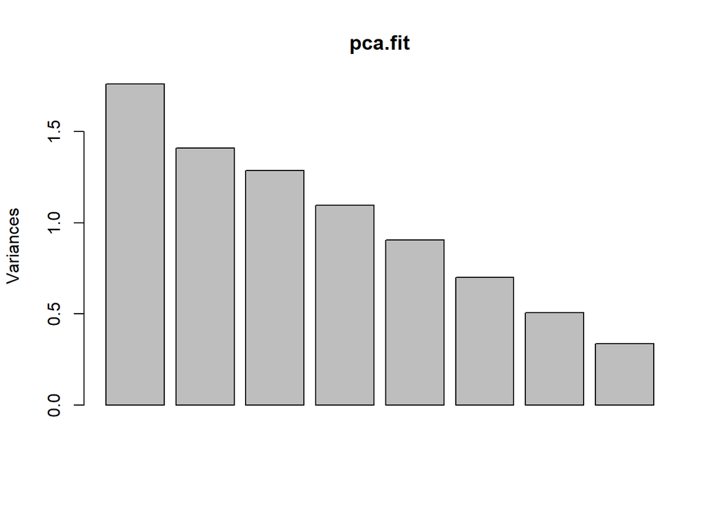

```r
plot(pca.fit)
```

```r
#print(pca.fit)
```

Построим scatter plot по первым двум главным компонентам.

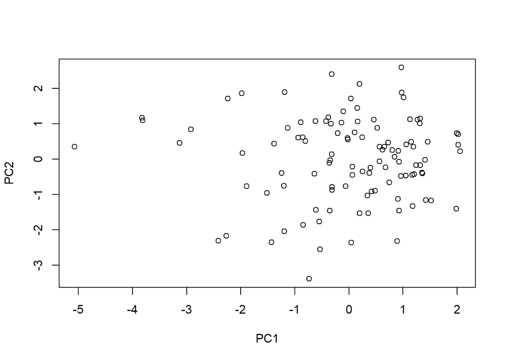

```r
plot(Z[,1], Z[,2],  xlab="PC1", ylab="PC2", pch=1)
```

Картина ожидаемая, т.к. вклад PC1 примерно равен вкладу PC2.

```r
pca.fit <- prcomp(X, rank.=2)
summary(pca.fit)
```

```
## Importance of first k=2 (out of 8) components:
##                           PC1    PC2
## Standard deviation     1.3273 1.1867
## Proportion of Variance 0.2202 0.1760
## Cumulative Proportion  0.2202 0.3962
```

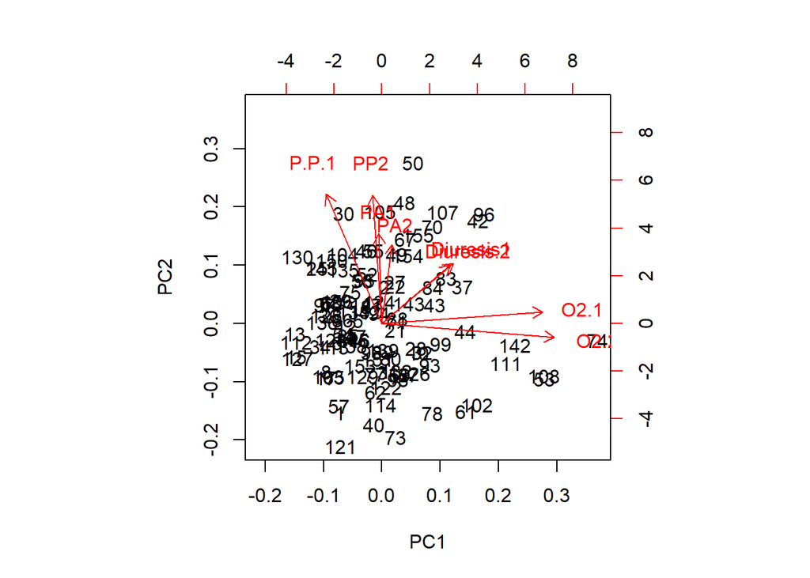

```r
biplot(pca.fit)
```

Чтобы ответить на вопрос о дифференциации факторов по признакам therapy и BLD проведем многомерный дисперсионный анализ.

```r
df$BLD <- as.factor(df$BLD)
df$therapy <- as.factor(df$therapy)

aov.fit <- aov(V[,1] ~ BLD + therapy + BLD:therapy, df)
summary(aov.fit)
```

```
##             Df Sum Sq Mean Sq F value   Pr(>F)
## BLD          4 0.4877 0.12193   7.315 3.57e-05 ***
## therapy      2 0.0801 0.04007   2.404   0.0959 .
## BLD:therapy  6 0.0930 0.01550   0.930   0.4773
## Residuals   94 1.5668 0.01667
## ---
## Signif. codes:  0 '***' 0.001 '**' 0.01 '*' 0.05 '.' 0.1 ' ' 1
```

```r
aov.fit <- aov(V[,2] ~ BLD + therapy + BLD:therapy, df)
summary(aov.fit)
```

```
##             Df Sum Sq Mean Sq F value Pr(>F)
## BLD          4 0.1248 0.03121   2.083 0.0891 .
## therapy      2 0.0576 0.02879   1.922 0.1521
## BLD:therapy  6 0.0826 0.01376   0.919 0.4852
## Residuals   94 1.4081 0.01498
## ---
## Signif. codes:  0 '***' 0.001 '**' 0.01 '*' 0.05 '.' 0.1 ' ' 1
```

```r
aov.fit <- manova(V[,1:2] ~ BLD + therapy + BLD:therapy, df)
summary(aov.fit)
```

```
##             Df  Pillai approx F num Df den Df    Pr(>F)
## BLD          4 0.32830   4.6151      8    188 3.679e-05 ***
## therapy      2 0.09673   2.3888      4    188    0.0525 .
## BLD:therapy  6 0.11165   0.9263     12    188    0.5218
## Residuals   94
## ---
## Signif. codes:  0 '***' 0.001 '**' 0.01 '*' 0.05 '.' 0.1 ' ' 1
```